# Recettes pour le Data Wrangling

### Importance du nettoyage des données ou “data wrangling”

Le *data wrangling* (ou préparation des données) est une étape fondamentale de toute analyse de données. Il consiste à transformer des données brutes, souvent désordonnées ou incomplètes, en un jeu de données propre, structuré et prêt à être analysé.

Ce document est conçu comme un **livre de recettes** : chaque section présente un problème courant de manipulation des données et propose une solution claire et reproductible en utilisant l’écosystème **tidyverse**.

### Vue d’ensemble de la philosophie du tidyverse

Le **tidyverse** est un ensemble de packages R guidés par les principes des *tidy data*.

Trois principes fondamentaux définissent un jeu de données *tidy* :

- Chaque colonne contient une seule variable
- Chaque ligne correspond à une seule observation
- Chaque valeur possède sa propre cellule

  Ces principes visent à rendre les données plus faciles à manipuler, analyser et visualiser de manière cohérente et reproductible.

La structure “Tidy” simplifie la manipulation et l’analyse des données, en rendant les flux de travail intuitifs et reproductibles. Reposant sur une grammaire cohérente, les outils du **tidyverse** permettent une intégration fluide de tâches telles que le filtrage, la transformation et la visualisation des données, garantissant clarté et efficacité.

### Principaux packages du tidyverse pour le data wrangling (`readr`, `dplyr`, `tidyr`)

**readr** : permet une importation rapide et conviviale des données à partir de fichiers CSV, TSV et d’autres formats texte, avec une gestion flexible des types de colonnes et des encodages.

**dplyr** : se concentre sur la manipulation efficace des données en proposant des fonctions intuitives pour filtrer, résumer et transformer les jeux de données.

**tidyr** : est spécialisé dans la restructuration et l’organisation des jeux de données, en permettant de passer facilement entre les formats long et large, ainsi que de gérer les valeurs manquantes.

Ensemble, ces packages rationalisent le processus de préparation des données afin de les rendre directement exploitables pour l’analyse.

## Set-up

```r
# load tidyverse libraries
library(tibble)
library(readr)
library(dplyr)
library(tidyr)
# alternatively: library(tidyverse)

# load non-tidyverse libraries
library(writexl)
library(here)
```

## Charger, Générer, et Inspecter les données

### Charger les données à partir de fichiers

Recettes pour charger des données à partir de différents formats de fichiers

- **Recette 1a: charger des fichiers CSV (comma separated variables)**

  ```r
  df_data <- readr::read_csv(file = here::here("data/wrangling_files/synthetic_data_2024-11-24.csv"),

                  # consider the first row as column names
                  col_names = TRUE,
                  # ability to skip the N first rows if needed
                  skip = 0,
                  # ability to force variable type, by default it guesses
                  col_types = NULL)
  df_data
  ```

  ```
  # A tibble: 25 × 5
     Subject_Id   Age Sex    Biomarker_1 Biomarker_2
     <chr>      <dbl> <chr>        <dbl>       <dbl>
   1 SUBJ1       69.6 Female        195.        65.3
   2 SUBJ2       48.1 Female        193.        67.2
   3 SUBJ3       30.3 Female        132.        65.6
   4 SUBJ4       79.0 Female        104.        59.8
   5 SUBJ5       44.1 Female        130.        26.3
   6 SUBJ6       66.0 Female        167.        67.6
   7 SUBJ7       25.5 Male          161.        36.1
   8 SUBJ8       73.7 Female        195.        70.1
   9 SUBJ9       68.1 Female        194.        53.7
  10 SUBJ10      57.8 Male          181.        23.7
  # ℹ 15 more rows
  ```

- **Recette 1b: charger des fichiers TSV (tab separated variables)**

  ```r
  df_data <- readr::read_tsv(file=here::here("data/wrangling_files/synthetic_data_2024-11-24.tsv"),
                  # consider the first row as column names
                  col_names = TRUE,
                  # ability to skip the N first rows if needed
                  skip = 0,
                  # ability to force a variable type per column, by default it guesses
                  col_types = NULL)
  df_data
  ```

  ```
  # A tibble: 25 × 5
     Subject_Id   Age Sex    Biomarker_1 Biomarker_2
     <chr>      <dbl> <chr>        <dbl>       <dbl>
   1 SUBJ1       69.6 Female        195.        65.3
   2 SUBJ2       48.1 Female        193.        67.2
   3 SUBJ3       30.3 Female        132.        65.6
   4 SUBJ4       79.0 Female        104.        59.8
   5 SUBJ5       44.1 Female        130.        26.3
   6 SUBJ6       66.0 Female        167.        67.6
   7 SUBJ7       25.5 Male          161.        36.1
   8 SUBJ8       73.7 Female        195.        70.1
   9 SUBJ9       68.1 Female        194.        53.7
  10 SUBJ10      57.8 Male          181.        23.7
  # ℹ 15 more rows
  ```

  ```r
  # see also: readr::read_delim()
  ```

- **Recette 1c: charger des fichiers Excel (.xls ou .xlsx)**

  ```r
  df_data <- readxl::read_excel(path = here::here("data/wrangling_files/synthetic_data_2024-11-24.xlsx"),
                     # specify name or index of the sheet to read
                     sheet = "sheet_2",
                     # consider the first row for column names
                     col_names = TRUE,
                     # ability to skip the N first rows if needed
                     skip = 0,
                     # ability to force a variable type per column, by default it guesses
                     col_types = NULL)

  df_data
  ```

  ```
  # A tibble: 25 × 5
     Subject_Id   Age Sex    Biomarker_1 Biomarker_2
     <chr>      <dbl> <chr>        <dbl>       <dbl>
   1 SUBJ1       69.6 Female        195.        65.3
   2 SUBJ2       48.1 Female        193.        67.2
   3 SUBJ3       30.3 Female        132.        65.6
   4 SUBJ4       79.0 Female        104.        59.8
   5 SUBJ5       44.1 Female        130.        26.3
   6 SUBJ6       66.0 Female        167.        67.6
   7 SUBJ7       25.5 Male          161.        36.1
   8 SUBJ8       73.7 Female        195.        70.1
   9 SUBJ9       68.1 Female        194.        53.7
  10 SUBJ10      57.8 Male          181.        23.7
  # ℹ 15 more rows
  ```

### Génération de données synthétiques

La génération de **données synthétiques** est un outil précieux pour apprendre et s’entraîner à l’analyse de données *tidy*. Elle permet de travailler avec des jeux de données réalistes et contrôlés, sans se soucier des questions de confidentialité ou des restrictions d’accès. Les données synthétiques sont particulièrement utiles pour illustrer des flux de travail, tester des méthodes et déboguer du code de manière reproductible.

### Recette 2 : générer des données synthétiques

Un exemple montrant comment utiliser **R** pour générer un jeu de données synthétique en s’appuyant sur différentes stratégies d’échantillonnage.

```r
# set a random seed to promote reproducibility
# it is required as we use random generators
set.seed(42)

nb_subjects = 25
synthetic_data <- tibble::tibble(Subject_Id = paste0("SUBJ", 1:nb_subjects),
                                 # variable from a uniform distribution
                                 Age = runif(n = nb_subjects, min = 20, max = 80),
                                 # variable sample from define categories and probabilities
                                 Sex = sample(x = c("Male", "Female", NA), prob = c(0.3, 0.5, 0.2),
                                              size = nb_subjects, replace = TRUE),
                                 # variable from a normal distribution where standard deviation
                                 # depends on a continuous variable
                                 Biomarker_1 = rnorm(n = nb_subjects,
                                                     mean = 150,
                                                     sd = 10*Age*0.05),
                                 # variable from a normal distribution where the mean
                                 # conditionnaly depends on a categorical variable
                                 Biomarker_2 = rnorm(n = nb_subjects,
                                                     mean = dplyr::case_when(
                                                       Sex == "Female" ~ 60,
                                                       Sex == "Male" ~ 40,
                                                       .default = NA),
                                                     sd = 10))
synthetic_data
```

```
# A tibble: 25 × 5
   Subject_Id   Age Sex    Biomarker_1 Biomarker_2
   <chr>      <dbl> <chr>        <dbl>       <dbl>
 1 SUBJ1       74.9 Male          134.        43.2
 2 SUBJ2       76.2 Female        140.        52.2
 3 SUBJ3       37.2 <NA>          117.       NaN
 4 SUBJ4       69.8 Female        166.        75.8
 5 SUBJ5       58.5 <NA>          131.       NaN
 6 SUBJ6       51.1 Male          162.        46.4
 7 SUBJ7       64.2 <NA>          173.       NaN
 8 SUBJ8       28.1 Female        165.        60.9
 9 SUBJ9       59.4 Male          132.        42.8
10 SUBJ10      62.3 Female        166.        66.8
# ℹ 15 more rows
```

```r
# see also: ?Distributions for more examples of available distributions
```

### **Inspecter les données**

Des recettes pour explorer rapidement vos données et vérifier que l’importation s’est bien déroulée. Il est essentiel de toujours s’assurer que toutes les variables et observations attendues sont présentes, ainsi que de vérifier le type de données de chaque variable.

- **Recette 3a : aperçu rapide (quelques lignes seulement)**

Afficher les premières lignes de votre jeu de données.

```r
# looking at the top 5 rows
head(synthetic_data, n = 5)
```

```
# A tibble: 5 × 5
  Subject_Id   Age Sex    Biomarker_1 Biomarker_2
  <chr>      <dbl> <chr>        <dbl>       <dbl>
1 SUBJ1       74.9 Male          134.        43.2
2 SUBJ2       76.2 Female        140.        52.2
3 SUBJ3       37.2 <NA>          117.       NaN
4 SUBJ4       69.8 Female        166.        75.8
5 SUBJ5       58.5 <NA>          131.       NaN
```

```r
# see also: tail()
```

- **Recette 3b: voir la structure du jeu de données**

  ```r
  # provide the full list of variable with type, and sample values
  dplyr::glimpse(synthetic_data)
  ```

  ```
  Rows: 25
  Columns: 5
  $ Subject_Id  <chr> "SUBJ1", "SUBJ2", "SUBJ3", "SUBJ4", "SUBJ5", "SUBJ6", "SUB…
  $ Age         <dbl> 74.88836, 76.22452, 37.16837, 69.82686, 58.50473, 51.14576…
  $ Sex         <chr> "Male", "Female", NA, "Female", NA, "Male", NA, "Female", …
  $ Biomarker_1 <dbl> 133.8814, 140.1949, 117.2330, 166.0636, 131.2786, 161.6472…
  $ Biomarker_2 <dbl> 43.21925, 52.16161, NaN, 75.75728, NaN, 46.42899, NaN, 60.…
  ```

  ```r
  # voir aussi str(synthetic_data)
  ```

## Préparation des données

### Selection, Renommage and Reorganisation des colonnes

- **Recette 4a: selection des colonnes**

  ```r
  # use variable names to select them
  synthetic_data_mini <- synthetic_data |>
                          dplyr::select(Subject_Id, Age, Sex)
  synthetic_data_mini
  ```

  ```
  # A tibble: 25 × 3
     Subject_Id   Age Sex
     <chr>      <dbl> <chr>
   1 SUBJ1       74.9 Male
   2 SUBJ2       76.2 Female
   3 SUBJ3       37.2 <NA>
   4 SUBJ4       69.8 Female
   5 SUBJ5       58.5 <NA>
   6 SUBJ6       51.1 Male
   7 SUBJ7       64.2 <NA>
   8 SUBJ8       28.1 Female
   9 SUBJ9       59.4 Male
  10 SUBJ10      62.3 Female
  # ℹ 15 more rows
  ```

- **Recette 4b: Reorganisation des colonnes**

  ```r
  # swap column order according to list of variables provided
  synthetic_data |>
    dplyr::select(Subject_Id, Sex, Age, Biomarker_2, Biomarker_1)
  ```

  ```
  # A tibble: 25 × 5
     Subject_Id Sex      Age Biomarker_2 Biomarker_1
     <chr>      <chr>  <dbl>       <dbl>       <dbl>
   1 SUBJ1      Male    74.9        43.2        134.
   2 SUBJ2      Female  76.2        52.2        140.
   3 SUBJ3      <NA>    37.2       NaN          117.
   4 SUBJ4      Female  69.8        75.8        166.
   5 SUBJ5      <NA>    58.5       NaN          131.
   6 SUBJ6      Male    51.1        46.4        162.
   7 SUBJ7      <NA>    64.2       NaN          173.
   8 SUBJ8      Female  28.1        60.9        165.
   9 SUBJ9      Male    59.4        42.8        132.
  10 SUBJ10     Female  62.3        66.8        166.
  # ℹ 15 more rows
  ```

  ```r
  # see also: dplyr::relocate()
  ```

- **Recette 4c: Renommage des colonnes**

  ```r
  # rename column names
  synthetic_data |>
    dplyr::rename(DonorId = Subject_Id,
                  Age_VO = Age)
  ```

  ```
  # A tibble: 25 × 5
     DonorId Age_VO Sex    Biomarker_1 Biomarker_2
     <chr>    <dbl> <chr>        <dbl>       <dbl>
   1 SUBJ1     74.9 Male          134.        43.2
   2 SUBJ2     76.2 Female        140.        52.2
   3 SUBJ3     37.2 <NA>          117.       NaN
   4 SUBJ4     69.8 Female        166.        75.8
   5 SUBJ5     58.5 <NA>          131.       NaN
   6 SUBJ6     51.1 Male          162.        46.4
   7 SUBJ7     64.2 <NA>          173.       NaN
   8 SUBJ8     28.1 Female        165.        60.9
   9 SUBJ9     59.4 Male          132.        42.8
  10 SUBJ10    62.3 Female        166.        66.8
  # ℹ 15 more rows
  ```

### Reformatting Data Types

- **Recette 5a: convertion de caractères en facteurs**

  Convertir une colonne de type caractère en **facteur** permet de contrôler l’ordre des différents niveaux. Cela est important à la fois pour la visualisation (par exemple, ordonner les catégories d’un diagramme en barres) et pour l’analyse (par exemple, déterminer quel niveau sera utilisé comme référence).

  ```r
  # convert column to factor
  synthetic_data |>
    dplyr::mutate(Sex = factor(Sex, levels = c("Male", "Female")))
  ```

  ```
  # A tibble: 25 × 5
     Subject_Id   Age Sex    Biomarker_1 Biomarker_2
     <chr>      <dbl> <fct>        <dbl>       <dbl>
   1 SUBJ1       74.9 Male          134.        43.2
   2 SUBJ2       76.2 Female        140.        52.2
   3 SUBJ3       37.2 <NA>          117.       NaN
   4 SUBJ4       69.8 Female        166.        75.8
   5 SUBJ5       58.5 <NA>          131.       NaN
   6 SUBJ6       51.1 Male          162.        46.4
   7 SUBJ7       64.2 <NA>          173.       NaN
   8 SUBJ8       28.1 Female        165.        60.9
   9 SUBJ9       59.4 Male          132.        42.8
  10 SUBJ10      62.3 Female        166.        66.8
  # ℹ 15 more rows
  ```

- **Recette 5b: Conversion de caractères en chiffres**

  ```r
  # convert character column to numeric
  tibble(weight = c("55.1", "47.2", "63"),
         height = c("156", "188.2", "176.5")) |>
    dplyr::mutate(across(where(is.character), as.numeric))
  ```

  ```
  # A tibble: 3 × 2
    weight height
     <dbl>  <dbl>
  1   55.1   156
  2   47.2   188.
  3   63     176.
  ```

## Selectionner les Observations

### Ordonner les lignes

- **Recette 6a:** ordonner en fonction d’une ou plusieures colonnes

  desc() indique le sens contraire

  ```r
  synthetic_data |>
    # order by Sex categories, and decreasing Age
    dplyr::arrange(Sex, desc(Age))
  ```

  ```
  # A tibble: 25 × 5
     Subject_Id   Age Sex    Biomarker_1 Biomarker_2
     <chr>      <dbl> <chr>        <dbl>       <dbl>
   1 SUBJ17      78.7 Female        136.        61.9
   2 SUBJ16      76.4 Female        158.        56.3
   3 SUBJ2       76.2 Female        140.        52.2
   4 SUBJ13      76.1 Female        118.        30.1
   5 SUBJ4       69.8 Female        166.        75.8
   6 SUBJ12      63.1 Female        125.        60.9
   7 SUBJ10      62.3 Female        166.        66.8
   8 SUBJ20      53.6 Female        113.        74.0
   9 SUBJ8       28.1 Female        165.        60.9
  10 SUBJ18      27.0 Female        160.        65.8
  # ℹ 15 more rows
  ```

### Filtrer les observations

- **Recette 6b: filtrer en utilisant des conditions sur les colonnes**

  ```r
  synthetic_data |>
    # look for rows where Age < 30 AND Sex is Female
    dplyr::filter(Age < 30, Sex == "Female")
  ```

  ```
  # A tibble: 2 × 5
    Subject_Id   Age Sex    Biomarker_1 Biomarker_2
    <chr>      <dbl> <chr>        <dbl>       <dbl>
  1 SUBJ8       28.1 Female        165.        60.9
  2 SUBJ18      27.0 Female        160.        65.8
  ```

- **Recette 6b: enlever les données manquantes d’une colonne par lignes**

  ```r
  synthetic_data |>
    # look for rows where Sex is NOT NA
    dplyr::filter(!is.na(Sex))
  ```

  ```
  # A tibble: 16 × 5
     Subject_Id   Age Sex    Biomarker_1 Biomarker_2
     <chr>      <dbl> <chr>        <dbl>       <dbl>
   1 SUBJ1       74.9 Male          134.        43.2
   2 SUBJ2       76.2 Female        140.        52.2
   3 SUBJ4       69.8 Female        166.        75.8
   4 SUBJ6       51.1 Male          162.        46.4
   5 SUBJ8       28.1 Female        165.        60.9
   6 SUBJ9       59.4 Male          132.        42.8
   7 SUBJ10      62.3 Female        166.        66.8
   8 SUBJ12      63.1 Female        125.        60.9
   9 SUBJ13      76.1 Female        118.        30.1
  10 SUBJ15      47.7 Male          151.        42.8
  11 SUBJ16      76.4 Female        158.        56.3
  12 SUBJ17      78.7 Female        136.        61.9
  13 SUBJ18      27.0 Female        160.        65.8
  14 SUBJ20      53.6 Female        113.        74.0
  15 SUBJ23      79.3 Male          207.        32.7
  16 SUBJ25      24.9 Male          158.        53.0
  ```

### Selection des Colonnes

- **Recette 7a: selection de colonnes par nom ou motif**

  ```r
  # select subject_id column, and any column names containing string "Biomarker"
  synthetic_data |>
    dplyr::select(Subject_Id, tidyselect::contains("Biomarker"))
  ```

  ```
  # A tibble: 25 × 3
     Subject_Id Biomarker_1 Biomarker_2
     <chr>            <dbl>       <dbl>
   1 SUBJ1             134.        43.2
   2 SUBJ2             140.        52.2
   3 SUBJ3             117.       NaN
   4 SUBJ4             166.        75.8
   5 SUBJ5             131.       NaN
   6 SUBJ6             162.        46.4
   7 SUBJ7             173.       NaN
   8 SUBJ8             165.        60.9
   9 SUBJ9             132.        42.8
  10 SUBJ10            166.        66.8
  # ℹ 15 more rows
  ```

  ```r
  # see also: tidyselect::start_with(), ends_with(), matches()
  ```

- **Recette 7b: Enlever une colonne par nom**

  ```r
  # remove Age and Sex columns by using the minus symbol
  synthetic_data |>
    dplyr::select(-Age, -Sex)
  ```

  ```
  # A tibble: 25 × 3
     Subject_Id Biomarker_1 Biomarker_2
     <chr>            <dbl>       <dbl>
   1 SUBJ1             134.        43.2
   2 SUBJ2             140.        52.2
   3 SUBJ3             117.       NaN
   4 SUBJ4             166.        75.8
   5 SUBJ5             131.       NaN
   6 SUBJ6             162.        46.4
   7 SUBJ7             173.       NaN
   8 SUBJ8             165.        60.9
   9 SUBJ9             132.        42.8
  10 SUBJ10            166.        66.8
  # ℹ 15 more rows
  ```

### Creation et Transformation de Variables

- **Recette 8a: ajouter une nouvelle variable**

  ```r
  # create a new variable based on existing ones
  synthetic_data |> dplyr::mutate(Biomarker_Ratio = Biomarker_2/Biomarker_1)
  ```

  ```
  # A tibble: 25 × 6
     Subject_Id   Age Sex    Biomarker_1 Biomarker_2 Biomarker_Ratio
     <chr>      <dbl> <chr>        <dbl>       <dbl>           <dbl>
   1 SUBJ1       74.9 Male          134.        43.2           0.323
   2 SUBJ2       76.2 Female        140.        52.2           0.372
   3 SUBJ3       37.2 <NA>          117.       NaN           NaN
   4 SUBJ4       69.8 Female        166.        75.8           0.456
   5 SUBJ5       58.5 <NA>          131.       NaN           NaN
   6 SUBJ6       51.1 Male          162.        46.4           0.287
   7 SUBJ7       64.2 <NA>          173.       NaN           NaN
   8 SUBJ8       28.1 Female        165.        60.9           0.370
   9 SUBJ9       59.4 Male          132.        42.8           0.324
  10 SUBJ10      62.3 Female        166.        66.8           0.403
  # ℹ 15 more rows
  ```

- **Recette 8b: normalisation d’une variable basée sur le z-score**

```r
synthetic_data |>
  dplyr::mutate(Biomarker1_zscore = scale(Biomarker_1, center = TRUE, scale=TRUE))
```

```
# A tibble: 25 × 6
   Subject_Id   Age Sex    Biomarker_1 Biomarker_2 Biomarker1_zscore[,1]
   <chr>      <dbl> <chr>        <dbl>       <dbl>                 <dbl>
 1 SUBJ1       74.9 Male          134.        43.2                -0.421
 2 SUBJ2       76.2 Female        140.        52.2                -0.157
 3 SUBJ3       37.2 <NA>          117.       NaN                  -1.12
 4 SUBJ4       69.8 Female        166.        75.8                 0.925
 5 SUBJ5       58.5 <NA>          131.       NaN                  -0.529
 6 SUBJ6       51.1 Male          162.        46.4                 0.740
 7 SUBJ7       64.2 <NA>          173.       NaN                   1.20
 8 SUBJ8       28.1 Female        165.        60.9                 0.861
 9 SUBJ9       59.4 Male          132.        42.8                -0.503
10 SUBJ10      62.3 Female        166.        66.8                 0.911
# ℹ 15 more rows
```

- **Recette 8c: modification d’une variable caractère avec le package StringR**

```r
# replace the prefix from a character variable
synthetic_data |>
  dplyr::mutate(Subject_Id = stringr::str_replace(Subject_Id,
                pattern = "SUBJ",
                replacement = "Donor_"))
```

```
# A tibble: 25 × 5
   Subject_Id   Age Sex    Biomarker_1 Biomarker_2
   <chr>      <dbl> <chr>        <dbl>       <dbl>
 1 Donor_1     74.9 Male          134.        43.2
 2 Donor_2     76.2 Female        140.        52.2
 3 Donor_3     37.2 <NA>          117.       NaN
 4 Donor_4     69.8 Female        166.        75.8
 5 Donor_5     58.5 <NA>          131.       NaN
 6 Donor_6     51.1 Male          162.        46.4
 7 Donor_7     64.2 <NA>          173.       NaN
 8 Donor_8     28.1 Female        165.        60.9
 9 Donor_9     59.4 Male          132.        42.8
10 Donor_10    62.3 Female        166.        66.8
# ℹ 15 more rows
```

```r
# See ?stringr for more string manipulation options
# https://stringr.tidyverse.org
```

- **Recette 8d: appliquer une fonction à plusieures colonnes**

  ```r
  # apply the log transformation across all columns with Biomarker in their name
  synthetic_data |>
    dplyr::mutate(across(contains("Biomarker"),
                         # function to apply. '~' is used to specify a function
                         ~ log(.x),
                         # name transformed columns according to col name + "_log"
                         # if not specified, it overwrites the variables
                         .names = "{.col}_log"))
  ```

  ```
  # A tibble: 25 × 7
     Subject_Id   Age Sex    Biomarker_1 Biomarker_2 Biomarker_1_log
     <chr>      <dbl> <chr>        <dbl>       <dbl>           <dbl>
   1 SUBJ1       74.9 Male          134.        43.2            4.90
   2 SUBJ2       76.2 Female        140.        52.2            4.94
   3 SUBJ3       37.2 <NA>          117.       NaN              4.76
   4 SUBJ4       69.8 Female        166.        75.8            5.11
   5 SUBJ5       58.5 <NA>          131.       NaN              4.88
   6 SUBJ6       51.1 Male          162.        46.4            5.09
   7 SUBJ7       64.2 <NA>          173.       NaN              5.15
   8 SUBJ8       28.1 Female        165.        60.9            5.10
   9 SUBJ9       59.4 Male          132.        42.8            4.88
  10 SUBJ10      62.3 Female        166.        66.8            5.11
  # ℹ 15 more rows
  # ℹ 1 more variable: Biomarker_2_log <dbl>
  ```

### Gérer les données manquantes

- **Recette 9a: Detection des données manquantes**

  ```r
  synthetic_data |>
    # identify any rows where there is a NA value
    dplyr::filter(dplyr::if_any(everything(), ~ is.na(.x)))
  ```

  ```
  # A tibble: 9 × 5
    Subject_Id   Age Sex   Biomarker_1 Biomarker_2
    <chr>      <dbl> <chr>       <dbl>       <dbl>
  1 SUBJ3       37.2 <NA>         117.         NaN
  2 SUBJ5       58.5 <NA>         131.         NaN
  3 SUBJ7       64.2 <NA>         173.         NaN
  4 SUBJ11      47.5 <NA>         109.         NaN
  5 SUBJ14      35.3 <NA>         107.         NaN
  6 SUBJ19      48.5 <NA>         132.         NaN
  7 SUBJ21      74.2 <NA>         166.         NaN
  8 SUBJ22      28.3 <NA>         139.         NaN
  9 SUBJ24      76.8 <NA>         133.         NaN
  ```

  ```r
  # see also:  filter(if_all(everything(), ~ !is.na(.x)))
  ```

- **Recette 9b: enlever les observations avec données manquantes**

  ```r
  # drop rows with any missing value
  synthetic_data |> tidyr::drop_na()
  ```

  ```
  # A tibble: 16 × 5
     Subject_Id   Age Sex    Biomarker_1 Biomarker_2
     <chr>      <dbl> <chr>        <dbl>       <dbl>
   1 SUBJ1       74.9 Male          134.        43.2
   2 SUBJ2       76.2 Female        140.        52.2
   3 SUBJ4       69.8 Female        166.        75.8
   4 SUBJ6       51.1 Male          162.        46.4
   5 SUBJ8       28.1 Female        165.        60.9
   6 SUBJ9       59.4 Male          132.        42.8
   7 SUBJ10      62.3 Female        166.        66.8
   8 SUBJ12      63.1 Female        125.        60.9
   9 SUBJ13      76.1 Female        118.        30.1
  10 SUBJ15      47.7 Male          151.        42.8
  11 SUBJ16      76.4 Female        158.        56.3
  12 SUBJ17      78.7 Female        136.        61.9
  13 SUBJ18      27.0 Female        160.        65.8
  14 SUBJ20      53.6 Female        113.        74.0
  15 SUBJ23      79.3 Male          207.        32.7
  16 SUBJ25      24.9 Male          158.        53.0
  ```

  ```r
  # see also, drop_na(Subject_Id, Sex) to drop only if Subject_Id et Sex have missing values
  ```

- **Recette 9c: enlever les colonnes avec données manquantes**

  ```r
  synthetic_data |>
    # select all columns where there is no missing data
    select(where(~ !any(is.na(.))))
  ```

  ```
  # A tibble: 25 × 3
     Subject_Id   Age Biomarker_1
     <chr>      <dbl>       <dbl>
   1 SUBJ1       74.9        134.
   2 SUBJ2       76.2        140.
   3 SUBJ3       37.2        117.
   4 SUBJ4       69.8        166.
   5 SUBJ5       58.5        131.
   6 SUBJ6       51.1        162.
   7 SUBJ7       64.2        173.
   8 SUBJ8       28.1        165.
   9 SUBJ9       59.4        132.
  10 SUBJ10      62.3        166.
  # ℹ 15 more rows
  ```

  ```r
  #see also: select(where(~ !all(is.na(.))))
  ```

## Aggregation et calculs sur les observations

### Calculs sur les observations

- **Recette 10a: Statistiques descriptives (Moyenne, Median, etc.)**

```r
synthetic_data |> summarise(Age_Mean = mean(Age, na.rm = TRUE),
                            Age_Median = median(Age, na.rm = TRUE),
                            Biomarker_1_sd = sd(Biomarker_1, na.rm = TRUE))
```

```
# A tibble: 1 × 3
  Age_Mean Age_Median Biomarker_1_sd
     <dbl>      <dbl>          <dbl>
1     56.8       59.4           23.9
```

```r
# Note: more useful in the context of group_by operations
```

- **Recette 10b: Calculs sur plusieurs variables à la fois**

```r
synthetic_data |>
  # compute overall summaries
  dplyr::summarise(
    # on columns that are of type numeric, compute median value
    across(where(is.numeric), ~median(.x, na.rm = TRUE), .names = "median_{.col}"))
```

```
# A tibble: 1 × 3
  median_Age median_Biomarker_1 median_Biomarker_2
       <dbl>              <dbl>              <dbl>
1       59.4               139.               54.7
```

### Operations groupées

- **Recette 11b: Calculs par groupe**

  ```r
  synthetic_data |>
    # compute by group according to Sex variable.
    dplyr::group_by(Sex) |>
    # compute overall summaries
    dplyr::summarise(
      # on columns that are of type numeric, compute median value
      across(where(is.numeric), ~median(.x, na.rm = TRUE), .names = "median_{.col}"),
      # on specific columns, compute min value
      across(c(Age, Biomarker_1), ~min(.x, na.rm = TRUE), .names = "min_{.col}"))
  ```

  ```
  # A tibble: 3 × 6
    Sex   median_Age median_Biomarker_1 median_Biomarker_2 min_Age min_Biomarker_1
    <chr>      <dbl>              <dbl>              <dbl>   <dbl>           <dbl>
  1 Fema…       66.5               149.               61.4    27.0            113.
  2 Male        55.3               155.               43.0    24.9            132.
  3 <NA>        48.5               132.               NA      28.3            107.
  ```

## Mise en forme des données

### Transposer les données

La **transposition de données** est une compétence essentielle pour transformer des jeux de données entre les formats large et long, permettant une analyse et une visualisation plus efficaces. En format large, les données sont souvent plus faciles à lire, mais moins adaptées aux tâches de calcul. La transposition vers un format long structure les données selon les principes de la « tidy data », où chaque ligne représente une observation unique, ce qui les rend compatibles avec les fonctions de synthèse, de modélisation et de traçage (par exemple, ggplot2). À l’inverse, le retour à un format large est indispensable pour générer des tableaux récapitulatifs ou des rapports. Maîtriser la transposition des données offre une grande flexibilité dans la gestion des jeux de données et optimise les processus de travail pour diverses tâches analytiques.

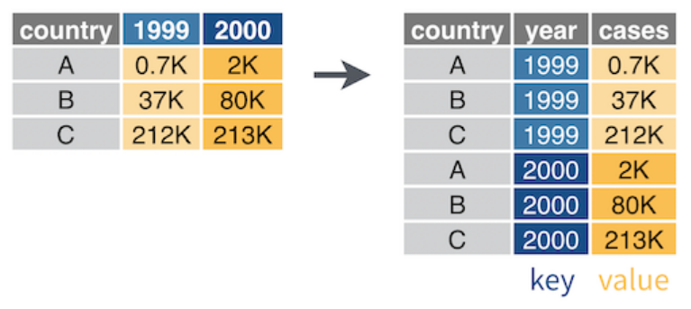

- **Recette 12a: Wide-to-Long Transformations**

  ```r
  # define table with wide format
  df_measurements <- tibble::tibble(id = 1:10,
                                    wk1 = rnorm(n = 10, mean = 10),
                                    wk2 = rnorm(n = 10, mean = 12),
                                    wk3 = rnorm(n = 10, mean = 15))

  df_measurements_long <- df_measurements |>
    # transform to long format by collapsing the columns starting with "wk"
    pivot_longer(
      cols = starts_with("wk"),
      names_to = "week",
      #names_prefix = "wk",
      values_to = "measurements",
      values_drop_na = TRUE
    )
  head(df_measurements_long)
  ```

  ```
  # A tibble: 6 × 3
       id week  measurements
    <int> <chr>        <dbl>
  1     1 wk1           10.3
  2     1 wk2           12.8
  3     1 wk3           14.8
  4     2 wk1           11.0
  5     2 wk2           12.5
  6     2 wk3           14.8
  ```

- **Recette 12b: Long-to-Wide Transformations**

  ```r
  # inverse transformation from long to wide
  df_measurements_long %>%
    pivot_wider(names_from = week, values_from = measurements) |>
    head()
  ```

  ```
  # A tibble: 6 × 4
       id   wk1   wk2   wk3
    <int> <dbl> <dbl> <dbl>
  1     1 10.3   12.8  14.8
  2     2 11.0   12.5  14.8
  3     3 10.9   11.1  15.9
  4     4 10.7   10.9  15.8
  5     5  8.96  13.5  16.4
  6     6  9.91  12.3  14.5
  ```

## Combiner and Fusionner les données

### Fusionner les données

Pour fusionner deux data frames dans R en fonction de colonnes d’ID spécifiques, vous pouvez utiliser le package **dplyr**. Voici quatre méthodes pour joindre les data frames, en veillant à ce que les observations soient correctement appariées, indépendamment de leur ordre :

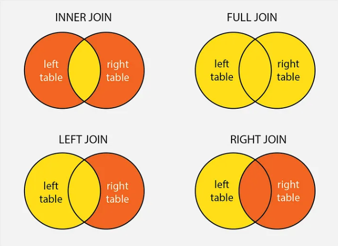

**left_join()** : Combine les data frames en conservant toutes les lignes du data frame de gauche et les lignes correspondantes du data frame de droite. Toutes les lignes du data frame de gauche sont incluses dans le résultat final.

**right_join()** : Conserve toutes les lignes du data frame de droite et inclut les lignes correspondantes du data frame de gauche. C’est l’inverse de left_join().

**inner_join()** : Ne garde que les lignes dont les ID correspondent dans les deux data frames, excluant celles qui ne trouvent pas de correspondance.

**full_join()** : Inclut toutes les lignes des deux data frames, en complétant par des NA les valeurs manquantes lorsqu’il n’y a pas de correspondance entre les colonnes d’ID.

- **Recette 14a: Different Types of Joins (Inner, Outer, Left, Right)**

  ```r
  # create table to merge with similar subject identifier (but different column name)
  df_data <- tibble(DonorId = paste0("SUBJ", 5:10),
                    Biomarker_3 = rnorm(n = 6, mean = 24, sd = 4))
  # Left join to keep all the records from synthetic data, and add new data when matching on Subject_Id
  df_merge <- synthetic_data |> dplyr::left_join(df_data, by = c("Subject_Id" = "DonorId"))
  head(df_merge, n=11)
  ```

  ```
  # A tibble: 11 × 6
     Subject_Id   Age Sex    Biomarker_1 Biomarker_2 Biomarker_3
     <chr>      <dbl> <chr>        <dbl>       <dbl>       <dbl>
   1 SUBJ1       74.9 Male          134.        43.2        NA
   2 SUBJ2       76.2 Female        140.        52.2        NA
   3 SUBJ3       37.2 <NA>          117.       NaN          NA
   4 SUBJ4       69.8 Female        166.        75.8        NA
   5 SUBJ5       58.5 <NA>          131.       NaN          19.5
   6 SUBJ6       51.1 Male          162.        46.4        18.2
   7 SUBJ7       64.2 <NA>          173.       NaN          24.3
   8 SUBJ8       28.1 Female        165.        60.9        26.6
   9 SUBJ9       59.4 Male          132.        42.8        28.8
  10 SUBJ10      62.3 Female        166.        66.8        28.2
  11 SUBJ11      47.5 <NA>          109.       NaN          NA
  ```

  ```r
  # see also: right_join(), inner_join(), outer_join()
  ```

### Combiner les lignes

- **Recette 15a: ajouter des lignes d’une autre data.frame**

  ```r
  df_data <- tibble(Subject_Id = paste0("SUBJ", 100:103),
                    Age = 25,
                    Sex = "Male")
  new_data <-synthetic_data |>
              # binding rows only works on table with same column names
              dplyr::select(Subject_Id, Age, Sex) |>
              # add 'df_data' rows at the bottom of synthetic_data
              dplyr::bind_rows(df_data)
  tail(new_data)
  ```

  ```
  # A tibble: 6 × 3
    Subject_Id   Age Sex
    <chr>      <dbl> <chr>
  1 SUBJ24      76.8 <NA>
  2 SUBJ25      24.9 Male
  3 SUBJ100     25   Male
  4 SUBJ101     25   Male
  5 SUBJ102     25   Male
  6 SUBJ103     25   Male
  ```

- **Recette 15b: enlever les duplicats**

  ```r
  synthetic_data |>
    dplyr::distinct()
  ```

  ```
  # A tibble: 25 × 5
     Subject_Id   Age Sex    Biomarker_1 Biomarker_2
     <chr>      <dbl> <chr>        <dbl>       <dbl>
   1 SUBJ1       74.9 Male          134.        43.2
   2 SUBJ2       76.2 Female        140.        52.2
   3 SUBJ3       37.2 <NA>          117.       NaN
   4 SUBJ4       69.8 Female        166.        75.8
   5 SUBJ5       58.5 <NA>          131.       NaN
   6 SUBJ6       51.1 Male          162.        46.4
   7 SUBJ7       64.2 <NA>          173.       NaN
   8 SUBJ8       28.1 Female        165.        60.9
   9 SUBJ9       59.4 Male          132.        42.8
  10 SUBJ10      62.3 Female        166.        66.8
  # ℹ 15 more rows
  ```

  ```r
  # see also distinct(Subject_Id, Sex)
  ```

## Exporter and Sauvergarder

- **Recette 16a: Writing Data as CSV Format**

  ```r
  readr::write_csv(x = synthetic_data,
                   col_names = TRUE,
                   file = here::here(paste0("data/wrangling_files/synthetic_data_", Sys.Date(),".csv")))
  ```

- **Recette 16b: Exporting Data as TSV Format**

  ```r
  readr::write_tsv(x = synthetic_data,
                   col_names = TRUE,
                   file = here::here(paste0("data/wrangling_files/synthetic_data_", Sys.Date(),".tsv")))
  # see also: readr::write_delim(x, file, delim = "\t")
  ```

- **Recette 16c: Exporting to Excel Files**

  ```r
  writexl::write_xlsx(x = list(sheet_1 = iris,
                               sheet_2 = synthetic_data),
                      col_names = TRUE,
                      path = here::here(paste0("data/wrangling_files/synthetic_data_", Sys.Date(),".xlsx")))
  ```

- **[Advanced] Recipe 16d:Saving and Loading R Objects**

  ```r
  # Save an R object as a compact binary format
  saveRDS(synthetic_data, file = here::here(paste0("data/wrangling_files/synthetic_data_", Sys.Date(),".rds")))

  # read R object from .rds file and assign it to a variable name
  df_data <- readRDS(file = here::here(paste0("data/wrangling_files/synthetic_data_2024-11-24.rds")))
  df_data
  ```

  ```
  # A tibble: 25 × 5
     Subject_Id   Age Sex    Biomarker_1 Biomarker_2
     <chr>      <dbl> <chr>        <dbl>       <dbl>
   1 SUBJ1       74.9 Male          134.        43.2
   2 SUBJ2       76.2 Female        140.        52.2
   3 SUBJ3       37.2 <NA>          117.       NaN
   4 SUBJ4       69.8 Female        166.        75.8
   5 SUBJ5       58.5 <NA>          131.       NaN
   6 SUBJ6       51.1 Male          162.        46.4
   7 SUBJ7       64.2 <NA>          173.       NaN
   8 SUBJ8       28.1 Female        165.        60.9
   9 SUBJ9       59.4 Male          132.        42.8
  10 SUBJ10      62.3 Female        166.        66.8
  # ℹ 15 more rows
  ```

## Continue learning with:

- [Tidyverse cookbook](https://rstudio-education.github.io/tidyverse-cookbook/)
- [Cheat Sheets on Tidyverse Packages](https://rstudio.github.io/cheatsheets/)
- [R For Data Science, free online book.](https://r4ds.hadley.nz/)
- [R Cookbook](https://rc2e.com/)